# Booming Billions: an Analysis on Global Wealth Data

Talyah Greyling

2025-06-19

### Abstract

This pdf document contains an analysis on a collection of global billionaires using data supplied by Forbes to uncover the underlying patterns to becoming one of the world’s wealthiest. Do developing countries deliver more self-made men? Is the software industry the key to a comfortable life? Read this paper to find out.

# 1 Introduction

Global wealth inequality has reached unprecedented levels, with just 8% of the world’s population owning 85% of its wealth and most of this being concentrated in the top 1% (Piketty, 2015). Against this backdrop, Forbes surveyed South Africa’s wealthiest individuals and identified a pressing need to analyze shifting wealth patterns across three decades—from the 1990s to the mid-2010s. With disparities widening both within and between nations (Mittelman, in press), this research aims to uncover critical insights that could inform future economic strategies. If successful, Forbes plans to expand this database, offering a vital tool to address one of today’s most urgent challenges: an increasingly unequal world.

## 1.1 Exploration Goals

Two main claims (made by one of Forbs’ participants) will be explored in this document: (1) “In the US, you saw an increasing number of new billionaires emerge that had little to no familial ties to generational wealth. Other developed markets and emerging markets tend to have less entrepreneurial successes and tend to house mostly inherited wealth.” (2) “Most new self-made millionaires are in software, compared to consumer services type industries in the 90s. This is related to different countries’ GDP, of course, with richer countries providing more innovation in consumer services.”

# 2 Exploring claim number 1

This claim entails comparing the prevalence of self-made billionaires in the US versus inherited wealth dominance in other developed and emerging markets.

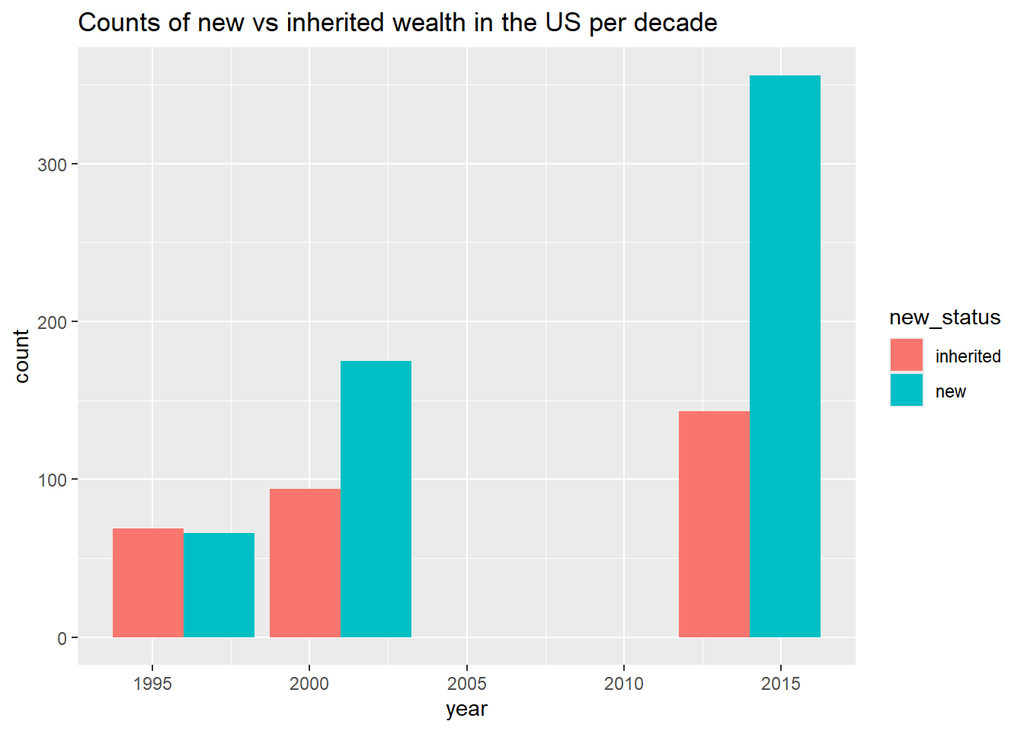

Figure 2.1: New vs. inherited wealth per decade (US)

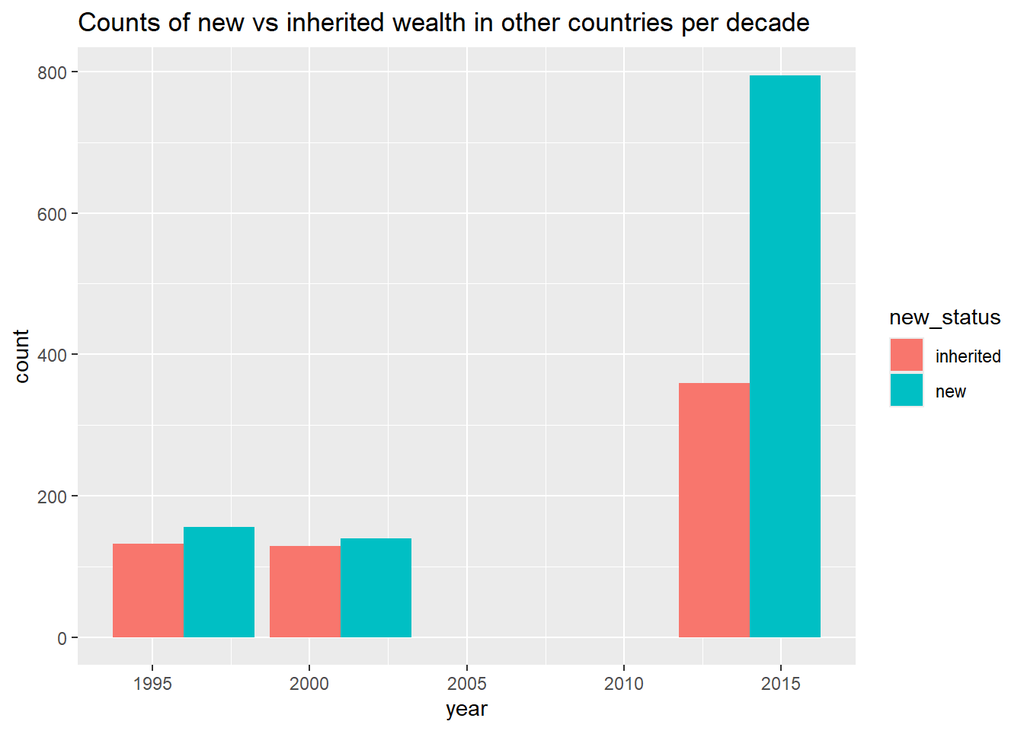

Figure 2.2: New vs. inherited wealth per decade (other countries)

The figure above depicts the counts of billionaires from other developed markets and emerging markets per decade who become rich by inheritance (indicated by the pink bars) or their own hard work (indicated by the blue bars). We see that in other countries the amount of self-made billionaires reduces slightly and then increases by a great magnitude, outnumbering the amount of billionaires by inheritance by a large margin. The billionaires by inheritance follow the same trajectory with a lesser increase in the final decade recorded. We therefore find the second part of the first claim, that these other markets tend to have less entrepreneurial successes and house mostly inherited wealth, to be false.

# 3 Exploring claim number 2

This claim entails analysing the shift from consumer services (1990s) to software as the primary industry for self-made millionaires, correlating with national GDP levels where the wealthier countries generate more billionaires in consumer services.

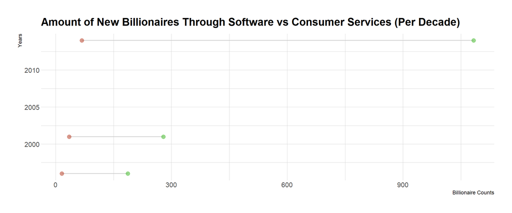

Figure 3.1: New Billionaires from Software vs Consumer Services (per decade)

The figure above depicts per decade the amount of new billionaires through software (indicated by the green dots) vs. consumer services (indicated by the red dots) who’s riches were the fruits of their own labour. We see that new billionaires by software already outnumber those from consumer services in the 90s and continue to increase by a greater amount than in consumer services in the subsequent decades. We therefore find the first part of the second claim, that most new self-made millionaires are in software, compared to consumer services type industries in the 90s to be true and continue to be true my a greater magnitude in the subsequent periods.

# 4 Conclusion

The data reveals a powerful trend: self-made success—driven by skill, persistence, or entrepreneurial luck—now dominates wealth creation globally, with software eclipsing traditional industries like consumer services as the fastest path to billionaire status. For those embracing this shift, the future holds extraordinary opportunity: the tools to build, innovate, and join this new elite are more accessible than ever. Your journey starts here.

# References

Mittelman, J.H. (in press). Paul collier: The bottom billion: Why the poorest countries are failing and what can be done about it. *Population and development review*. 33(4):821–.

Piketty, T. 2015. Putting distribution back at the center of economics: Reflections on "capital in the twenty-first century". *The Journal of economic perspectives*. 29(1):67–88.